# Autovanuse ennustamine kindlustusjuhtumi andmete järgi

Projekt õppeaines MEM5210 Mitmemõõtmeline statistiline analüüs

Koostajad: Vadim Aland, Vladimir Andrianov

Esitatud: 11.01.2021

# 1 Sissejuhatus

## 1.1 Andmestiku kirjeldus

Autorid valisid oma projekti jaoks andmestiku, mis sisaldab auto kindlustus juhtumite andmeid. Andmestik on võetud Kaggle.com veebilehe anmdestikude andmebaasist.  
Andmestik on .csv formaadis ja sisaldab 24 tunnust ja 7657 objekti.  
Tunnused:  
INDEX - identification variable (do not use)  
TARGET_FLAG - was car in a crash 1=yes 0=no  
TARGET_AMT - if car was in a crash, what was the cost  
AGE - age of driver  
BLUEBOOK - value of vehicle  
CAR_AGE - vehicle age  
CAR_TYPE - type of car  
CAR_USE - vehicle use  
CLM_FREQ - # claim past 5 years  
EDUCATION - max education level  
HOMEKIDS - # children at home  
HOME_VAL - home value  
INCOME - income  
JOB - job cathegory  
KIDSDRIV - # driving children  
MSTATUS - marital status  
MVR_PTS - motor vehicle record points  
OLDCLAIM - total claims past 5 years  
PARENT1 - single parent  
RED_CAR - a red car  
REVOKED - licence revoked past 7 years  
SEX - gender  
TIF - time in force  
TRAVTIME - distance to work  
URBANICITY - home/work area  
YOJ - years on job

## 1.2 Uurimiseesmärk

Projekti peaeesmärk on rakendada mitmemõõtmlise statistlise analüüsi õppeaines omandatatud meetodite rakendamist reaalsete andmete peal ning teha järeldusi ja tõlgendada neid.

## 1.3 Tööhüpoteesid

Kui auto sattus avariisse, faktorite järgi võib ennustada mis vanusegruppis auto on.

# 2 Uuringu käik

## 2.1 Andmestiku esmaanalüüs

Loeme andmed, kustutame kõik read kus on puuduvaid andmeid

Eemaldame ID, BIRTH ja CLAIM_FLAG tunnused. Kasutame ainult need andmed, kus CLM_AMT ei ole tühi

```r
carClaims = carClaims[c(2,4:25,27)]
carClaims = na.omit(carClaims)
```

Vaatame andmestiku suurust

```r
dim(carClaims)
```

```
## [1] 7657   24
```

Vaatame andmestiku struktuuri

```r
str(carClaims)
```

```
## 'data.frame':    7657 obs. of  24 variables:
##  $ KIDSDRIV  : int  0 0 0 0 0 1 0 0 0 0 ...
##  $ AGE       : int  60 43 48 35 34 40 44 34 50 53 ...
##  $ HOMEKIDS  : int  0 0 0 1 1 1 2 0 0 0 ...
##  $ YOJ       : int  11 11 11 10 12 11 12 10 7 14 ...
##  $ INCOME    : int  67349 91449 52881 16039 125301 50815 43486 62978 106952 77100 ...
##  $ PARENT1   : chr  "No" "No" "No" "No" ...
##  $ HOME_VAL  : int  0 257252 0 124191 0 0 0 0 0 0 ...
##  $ MSTATUS   : chr  "z_No" "z_No" "z_No" "Yes" ...
##  $ GENDER    : chr  "M" "M" "M" "z_F" ...
##  $ EDUCATION : chr  "PhD" "z_High School" "Bachelors" "z_High School" ...
##  $ OCCUPATION: chr  "Professional" "z_Blue Collar" "Manager" "Clerical" ...
##  $ TRAVTIME  : int  14 22 26 5 46 21 30 34 48 15 ...
##  $ CAR_USE   : chr  "Private" "Commercial" "Private" "Private" ...
##  $ BLUEBOOK  : int  14230 14940 21970 4010 17430 18930 5900 11200 18510 18300 ...
##  $ TIF       : int  11 1 1 4 1 6 10 1 7 1 ...
##  $ CAR_TYPE  : chr  "Minivan" "Minivan" "Van" "z_SUV" ...
##  $ RED_CAR   : chr  "yes" "yes" "yes" "no" ...
##  $ OLDCLAIM  : int  4461 0 0 38690 0 3295 0 0 0 0 ...
##  $ CLM_FREQ  : int  2 0 0 2 0 1 0 0 0 0 ...
##  $ REVOKED   : chr  "No" "No" "No" "No" ...
##  $ MVR_PTS   : int  3 0 2 3 0 2 0 0 1 0 ...
##  $ CLM_AMT   : int  0 0 0 0 2946 6477 0 2501 0 6077 ...
##  $ CAR_AGE   : int  18 1 10 10 7 1 10 1 17 11 ...
##  $ URBANICITY: chr  "Highly Urban/ Urban" "Highly Urban/ Urban" "Highly Urban/ Urban" "Highly Urban/ Urban" ...
##  - attr(*, "na.action")= 'omit' Named int [1:2645] 5 6 8 11 17 18 26 30 36 37 ...
##   ..- attr(*, "names")= chr [1:2645] "5" "6" "8" "11" ...
```

Vaatame andmestiku algust

```r
head(carClaims)
```

```
##   KIDSDRIV AGE HOMEKIDS YOJ INCOME PARENT1 HOME_VAL MSTATUS GENDER
## 1        0  60        0  11  67349      No        0    z_No      M
## 2        0  43        0  11  91449      No   257252    z_No      M
## 3        0  48        0  11  52881      No        0    z_No      M
## 4        0  35        1  10  16039      No   124191     Yes    z_F
## 7        0  34        1  12 125301     Yes        0    z_No    z_F
## 9        1  40        1  11  50815     Yes        0    z_No      M
##       EDUCATION    OCCUPATION TRAVTIME    CAR_USE BLUEBOOK TIF   CAR_TYPE
## 1           PhD  Professional       14    Private    14230  11    Minivan
## 2 z_High School z_Blue Collar       22 Commercial    14940   1    Minivan
## 3     Bachelors       Manager       26    Private    21970   1        Van
## 4 z_High School      Clerical        5    Private     4010   4      z_SUV
## 7     Bachelors z_Blue Collar       46 Commercial    17430   1 Sports Car
## 9 z_High School       Manager       21    Private    18930   6    Minivan
##   RED_CAR OLDCLAIM CLM_FREQ REVOKED MVR_PTS CLM_AMT CAR_AGE          URBANICITY
## 1     yes     4461        2      No       3       0      18 Highly Urban/ Urban
## 2     yes        0        0      No       0       0       1 Highly Urban/ Urban
## 3     yes        0        0      No       2       0      10 Highly Urban/ Urban
## 4      no    38690        2      No       3       0      10 Highly Urban/ Urban
## 7      no        0        0      No       0    2946       7 Highly Urban/ Urban
## 9      no     3295        1      No       2    6477       1 Highly Urban/ Urban
```

## 2.2 Andmete puhastamine

Konverteerime tüübid

```r
carClaims <- type.convert(carClaims)
```

Eemaldame kõik $ märgid andmestikust

```r
indx <- sapply(carClaims, is.factor)
carClaims[indx] <- lapply(carClaims[indx], function(x)
                            as.factor(gsub("\\$", "", x)))
```

```r
indx <- sapply(carClaims, is.factor)
carClaims[indx] <- lapply(carClaims[indx], function(x)
                            as.factor(gsub(",", "", x)))
```

Eemaldame kõik keeldud nõued (claim_amount=0)

```r
carClaims<-carClaims[!(carClaims$CLM_AMT==0),]
```

Uuendame tüübid uuesti, faktorid muutuvad arvulisteks tunnusteks

```r
carClaims <- type.convert(carClaims)
```

Uurime andmestiku ülevaade

```r
str(carClaims)
```

```
## 'data.frame':    2059 obs. of  24 variables:
##  $ KIDSDRIV  : int  0 1 0 0 0 0 0 0 0 0 ...
##  $ AGE       : int  34 40 34 53 45 59 28 60 32 40 ...
##  $ HOMEKIDS  : int  1 1 0 0 0 0 1 0 1 0 ...
##  $ YOJ       : int  12 11 10 14 0 12 13 12 9 11 ...
##  $ INCOME    : int  125301 50815 62978 77100 0 87460 44077 37940 31275 16989 ...
##  $ PARENT1   : chr  "Yes" "Yes" "No" "No" ...
##  $ HOME_VAL  : int  0 0 0 0 106859 0 170598 182739 118160 0 ...
##  $ MSTATUS   : chr  "z_No" "z_No" "z_No" "z_No" ...
##  $ GENDER    : chr  "z_F" "M" "z_F" "z_F" ...
##  $ EDUCATION : chr  "Bachelors" "z_High School" "Bachelors" "Masters" ...
##  $ OCCUPATION: chr  "z_Blue Collar" "Manager" "Clerical" "Lawyer" ...
##  $ TRAVTIME  : int  46 21 34 15 48 45 29 16 26 20 ...
##  $ CAR_USE   : chr  "Commercial" "Private" "Private" "Private" ...
##  $ BLUEBOOK  : int  17430 18930 11200 18300 6000 15420 8710 11290 10030 12230 ...
##  $ TIF       : int  1 6 1 1 1 1 6 1 1 4 ...
##  $ CAR_TYPE  : chr  "Sports Car" "Minivan" "z_SUV" "Sports Car" ...
##  $ RED_CAR   : chr  "no" "no" "no" "no" ...
##  $ OLDCLAIM  : int  0 3295 0 0 0 44857 8935 0 0 26104 ...
##  $ CLM_FREQ  : int  0 1 0 0 0 2 2 0 0 1 ...
##  $ REVOKED   : chr  "No" "No" "No" "No" ...
##  $ MVR_PTS   : int  0 2 0 0 3 4 0 0 0 13 ...
##  $ CLM_AMT   : int  2946 6477 2501 6077 2920 4111 6857 5247 4486 6100 ...
##  $ CAR_AGE   : int  7 1 1 11 5 1 1 1 1 6 ...
##  $ URBANICITY: chr  "Highly Urban/ Urban" "Highly Urban/ Urban" "Highly Urban/ Urban" "Highly Urban/ Urban" ...
##  - attr(*, "na.action")= 'omit' Named int [1:2645] 5 6 8 11 17 18 26 30 36 37 ...
##   ..- attr(*, "names")= chr [1:2645] "5" "6" "8" "11" ...
```

Uurime andmestiku kokkuvõtet

```r
summary(carClaims)
```

```
##     KIDSDRIV           AGE        HOMEKIDS          YOJ            INCOME
##  Min.   :0.0000   Min.   :16   Min.   :0.000   Min.   : 0.00   Min.   :     0
##  1st Qu.:0.0000   1st Qu.:36   1st Qu.:0.000   1st Qu.: 9.00   1st Qu.: 19093
##  Median :0.0000   Median :42   Median :0.000   Median :11.00   Median : 40868
##  Mean   :0.2525   Mean   :43   Mean   :0.966   Mean   :10.01   Mean   : 46652
##  3rd Qu.:0.0000   3rd Qu.:50   3rd Qu.:2.000   3rd Qu.:13.00   3rd Qu.: 66523
##  Max.   :3.0000   Max.   :76   Max.   :5.000   Max.   :19.00   Max.   :290846
##    PARENT1             HOME_VAL        MSTATUS             GENDER
##  Length:2059        Min.   :     0   Length:2059        Length:2059
##  Class :character   1st Qu.:     0   Class :character   Class :character
##  Mode  :character   Median :111256   Mode  :character   Mode  :character
##                     Mean   :111209
##                     3rd Qu.:192450
##                     Max.   :682634
##   EDUCATION          OCCUPATION           TRAVTIME       CAR_USE
##  Length:2059        Length:2059        Min.   : 5.00   Length:2059
##  Class :character   Class :character   1st Qu.:24.00   Class :character
##  Mode  :character   Mode  :character   Median :35.00   Mode  :character
##                                        Mean   :35.17
##                                        3rd Qu.:46.00
##                                        Max.   :89.00
##     BLUEBOOK          TIF           CAR_TYPE           RED_CAR
##  Min.   : 1500   Min.   : 1.000   Length:2059        Length:2059
##  1st Qu.: 7485   1st Qu.: 1.000   Class :character   Class :character
##  Median :12190   Median : 4.000   Mode  :character   Mode  :character
##  Mean   :13708   Mean   : 4.824
##  3rd Qu.:18520   3rd Qu.: 7.000
##  Max.   :48380   Max.   :21.000
##     OLDCLAIM        CLM_FREQ       REVOKED             MVR_PTS
##  Min.   :    0   Min.   :0.000   Length:2059        Min.   : 0.000
##  1st Qu.:    0   1st Qu.:0.000   Class :character   1st Qu.: 0.000
##  Median : 2610   Median :1.000   Mode  :character   Median : 2.000
##  Mean   : 6107   Mean   :1.234                      Mean   : 2.551
##  3rd Qu.: 6912   3rd Qu.:2.000                      3rd Qu.: 4.000
##  Max.   :57037   Max.   :5.000                      Max.   :13.000
##     CLM_AMT         CAR_AGE        URBANICITY
##  Min.   :   30   Min.   :-3.000   Length:2059
##  1st Qu.: 2588   1st Qu.: 1.000   Class :character
##  Median : 4127   Median : 7.000   Mode  :character
##  Mean   : 5505   Mean   : 6.765
##  3rd Qu.: 5686   3rd Qu.:10.000
##  Max.   :85524   Max.   :25.000
```

Eemaldame ekslikud andmed. Tühjad auto vanused ja negatiivsed auto vanused

```r
carClaims<-carClaims[!(carClaims$CAR_AGE<1),]
```

Sorteerime tegurid ja täisarvud erinevatesse andmestikutesse

```r
carClaimsFactors <- carClaims[,c(6,8:11,13,16,17,20,24)]
carClaimsNums <- carClaims[,c(1:5,7,12,14,15,18,19,21:23)]
str(carClaimsNums)
```

```
## 'data.frame':    2057 obs. of  14 variables:
##  $ KIDSDRIV: int  0 1 0 0 0 0 0 0 0 0 ...
##  $ AGE     : int  34 40 34 53 45 59 28 60 32 40 ...
##  $ HOMEKIDS: int  1 1 0 0 0 0 1 0 1 0 ...
##  $ YOJ     : int  12 11 10 14 0 12 13 12 9 11 ...
##  $ INCOME  : int  125301 50815 62978 77100 0 87460 44077 37940 31275 16989 ...
##  $ HOME_VAL: int  0 0 0 0 106859 0 170598 182739 118160 0 ...
##  $ TRAVTIME: int  46 21 34 15 48 45 29 16 26 20 ...
##  $ BLUEBOOK: int  17430 18930 11200 18300 6000 15420 8710 11290 10030 12230 ...
##  $ TIF     : int  1 6 1 1 1 1 6 1 1 4 ...
##  $ OLDCLAIM: int  0 3295 0 0 0 44857 8935 0 0 26104 ...
##  $ CLM_FREQ: int  0 1 0 0 0 2 2 0 0 1 ...
##  $ MVR_PTS : int  0 2 0 0 3 4 0 0 0 13 ...
##  $ CLM_AMT : int  2946 6477 2501 6077 2920 4111 6857 5247 4486 6100 ...
##  $ CAR_AGE : int  7 1 1 11 5 1 1 1 1 6 ...
```

```r
str(carClaimsFactors)
```

```
## 'data.frame':    2057 obs. of  10 variables:
##  $ PARENT1   : chr  "Yes" "Yes" "No" "No" ...
##  $ MSTATUS   : chr  "z_No" "z_No" "z_No" "z_No" ...
##  $ GENDER    : chr  "z_F" "M" "z_F" "z_F" ...
##  $ EDUCATION : chr  "Bachelors" "z_High School" "Bachelors" "Masters" ...
##  $ OCCUPATION: chr  "z_Blue Collar" "Manager" "Clerical" "Lawyer" ...
##  $ CAR_USE   : chr  "Commercial" "Private" "Private" "Private" ...
##  $ CAR_TYPE  : chr  "Sports Car" "Minivan" "z_SUV" "Sports Car" ...
##  $ RED_CAR   : chr  "no" "no" "no" "no" ...
##  $ REVOKED   : chr  "No" "No" "No" "No" ...
##  $ URBANICITY: chr  "Highly Urban/ Urban" "Highly Urban/ Urban" "Highly Urban/ Urban" "Highly Urban/ Urban" ...
```

## 2.3 Seoste analüüs

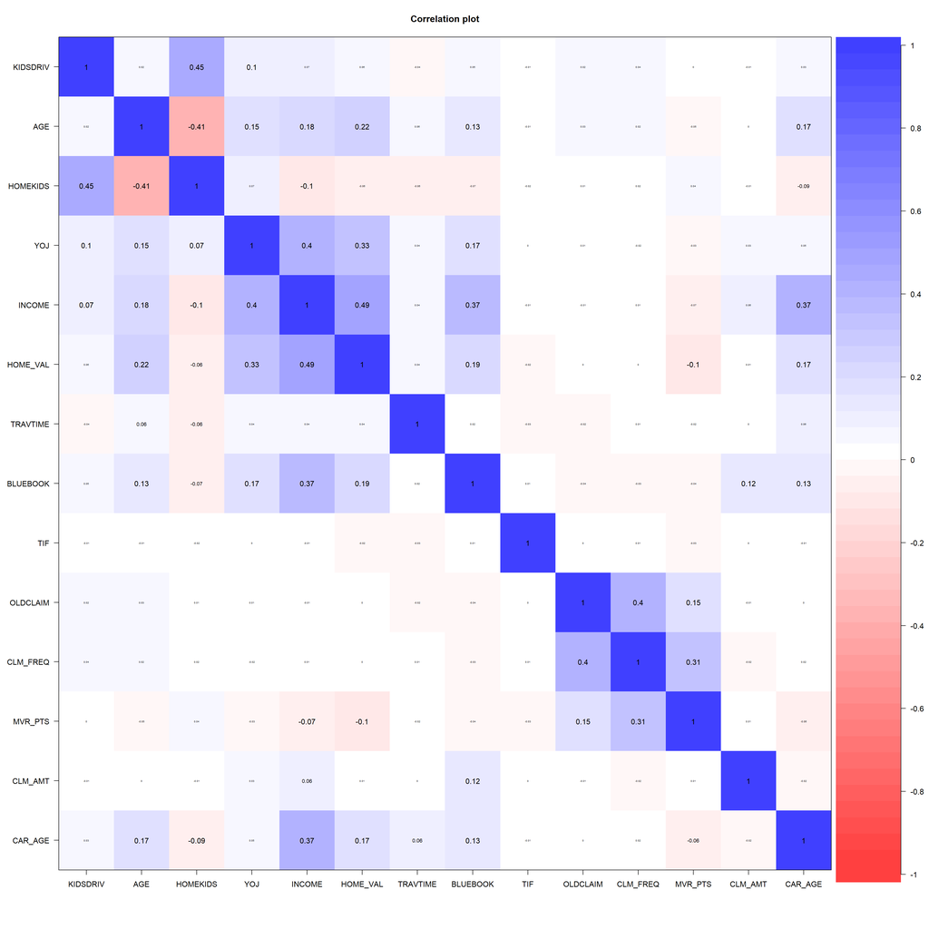

```r
library(psych)
cor.plot(carClaimsNums)
```

CAR AGE korreleerub kõige rohkem INCOME tunnusega, lisaks korrelleerub ka tunnustega HOME_VALUE, AGE ja BLUEBOOK

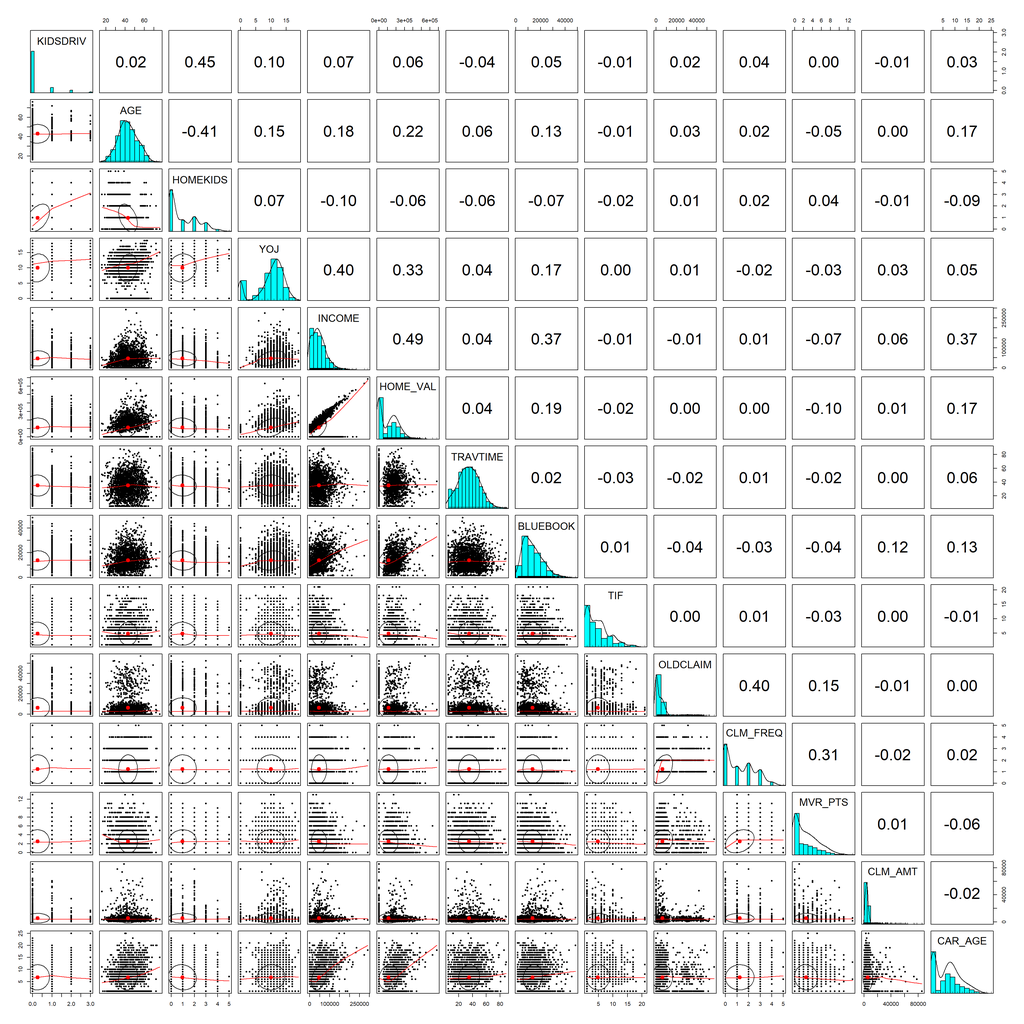

```r
library(psych)
pairs.panels(carClaimsNums)
```

CAR AGE korreleerub kõige rohkem INCOME tunnusega (0.37), kaks teist suurema korrellatsiooniga tunnust HOME_VALUE(0.17) ja AGE (0.17). Diagrammil on näha ka kõik rühmitatud tunnused, näiteks KIDSDRIV, HOMEKIDS, CLAIM_FREQ, MVR_PTS.

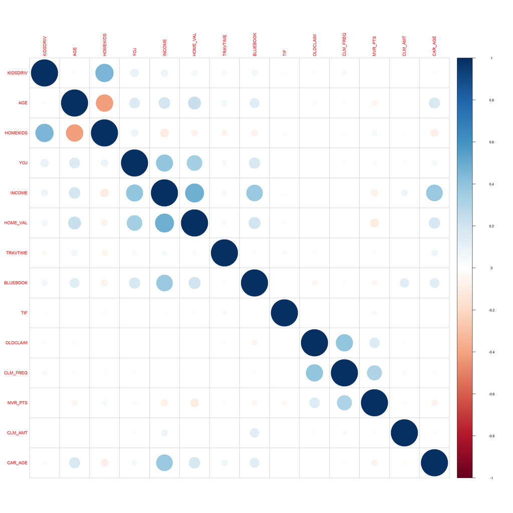

```r
library(corrplot)
corrplot(cor(carClaimsNums))
```

CAR AGE korreleerub kõige rohkem INCOME, AGE ja HOME_VALUE tunnustega

Meie hüpotees väidab, et kindlustus juhtumi andmete põhjal on võimalik auto vanust ennustada

## 2.4 MLR (sh sammregressioon)

Jagame andmeid kaheks osaks TEST/TRAIN andmestikud proportsioonides 80%/20%

Ehitame MLR mudel treeningandmetel, funktsioon-tunnusega Y=CAR_AGE

```r
n = nrow(carClaims)
RNGkind(sample.kind = "Rounding")
set.seed(123)
sample_index= sample(1:n,size=n,replace=F) #obj.indexit juhuslikult segatud
#treeningandmed 80%
train = sample_index[1:floor(n*.80)] #treeningandmete indeksi
test = sample_index[-train] #testandmete indeksid
carClaims_train=carClaims[train,] #treeningandmed
carClaims_test=carClaims[test,] #testandmed
```

Loome MLR mudel treeningandmetel

```r
mudel <- lm(CAR_AGE ~ .,data = carClaims_train)
summary(mudel)
```

```
##
## Call:
## lm(formula = CAR_AGE ~ ., data = carClaims_train)
##
## Residuals:
##     Min      1Q  Median      3Q     Max
## -13.237  -2.932   0.001   3.002  10.109
##
## Coefficients:
##                                   Estimate Std. Error t value Pr(>|t|)
## (Intercept)                      2.284e+00  8.126e-01   2.810  0.00501 **
## KIDSDRIV                        -1.370e-01  1.773e-01  -0.773  0.43985
## AGE                              1.523e-02  1.172e-02   1.300  0.19385
## HOMEKIDS                         1.032e-03  1.131e-01   0.009  0.99272
## YOJ                             -3.702e-03  2.662e-02  -0.139  0.88943
## INCOME                           2.932e-06  4.346e-06   0.675  0.49997
## PARENT1Yes                       2.543e-01  3.235e-01   0.786  0.43194
## HOME_VAL                         6.913e-07  1.221e-06   0.566  0.57134
## MSTATUSz_No                      4.084e-02  2.843e-01   0.144  0.88576
## GENDERz_F                        2.875e-01  3.556e-01   0.808  0.41901
## EDUCATIONBachelors               5.279e+00  3.280e-01  16.093  < 2e-16 ***
## EDUCATIONMasters                 1.062e+01  5.891e-01  18.023  < 2e-16 ***
## EDUCATIONPhD                     1.140e+01  7.402e-01  15.406  < 2e-16 ***
## EDUCATIONz_High School           8.282e-01  2.739e-01   3.023  0.00254 **
## OCCUPATIONDoctor                -1.809e+00  1.049e+00  -1.724  0.08488 .
## OCCUPATIONHome Maker            -1.619e-01  4.607e-01  -0.351  0.72534
## OCCUPATIONLawyer                -2.608e-01  6.577e-01  -0.397  0.69176
## OCCUPATIONManager               -4.076e-01  5.189e-01  -0.785  0.43228
## OCCUPATIONProfessional           2.611e-01  3.879e-01   0.673  0.50094
## OCCUPATIONStudent                6.906e-01  4.058e-01   1.702  0.08893 .
## OCCUPATIONz_Blue Collar          4.253e-01  3.172e-01   1.341  0.18020
## TRAVTIME                         4.331e-03  6.162e-03   0.703  0.48227
## CAR_USEPrivate                  -1.782e-01  2.861e-01  -0.623  0.53349
## BLUEBOOK                        -4.071e-06  1.708e-05  -0.238  0.81162
## TIF                              2.479e-02  2.318e-02   1.069  0.28508
## CAR_TYPEPanel Truck             -1.400e-01  5.522e-01  -0.254  0.79987
## CAR_TYPEPickup                   4.358e-02  3.187e-01   0.137  0.89127
## CAR_TYPESports Car              -1.300e-01  3.993e-01  -0.325  0.74487
## CAR_TYPEVan                     -4.061e-01  4.329e-01  -0.938  0.34834
## CAR_TYPEz_SUV                    4.609e-02  3.515e-01   0.131  0.89570
## RED_CARyes                       1.632e-02  2.779e-01   0.059  0.95318
## OLDCLAIM                        -6.486e-06  1.255e-05  -0.517  0.60541
## CLM_FREQ                         1.151e-01  8.727e-02   1.318  0.18756
## REVOKEDYes                       1.282e-01  2.875e-01   0.446  0.65586
## MVR_PTS                         -3.624e-02  3.769e-02  -0.962  0.33644
## CLM_AMT                         -3.166e-05  1.329e-05  -2.382  0.01732 *
## URBANICITYz_Highly Rural/ Rural -9.356e-03  4.166e-01  -0.022  0.98209
## ---
## Signif. codes:  0 '***' 0.001 '**' 0.01 '*' 0.05 '.' 0.1 ' ' 1
##
## Residual standard error: 3.716 on 1608 degrees of freedom
## Multiple R-squared:  0.4899, Adjusted R-squared:  0.4785
## F-statistic:  42.9 on 36 and 1608 DF,  p-value: < 2.2e-16
```

Mudeli kirjeldusvõime R2~49%

Mudeli RMSE:

```r
mudel_RMSE <- sqrt(sum(mudel$residuals^2)/length(mudel$residuals))
mudel_RMSE
```

```
## [1] 3.673968
```

Teeme sammregressioon mudeli parandamiseks

```r
mudel_step <- step(mudel)
```

```
## Start:  AIC=4355.19
## CAR_AGE ~ KIDSDRIV + AGE + HOMEKIDS + YOJ + INCOME + PARENT1 +
##     HOME_VAL + MSTATUS + GENDER + EDUCATION + OCCUPATION + TRAVTIME +
##     CAR_USE + BLUEBOOK + TIF + CAR_TYPE + RED_CAR + OLDCLAIM +
##     CLM_FREQ + REVOKED + MVR_PTS + CLM_AMT + URBANICITY
##
##              Df Sum of Sq   RSS    AIC
## - CAR_TYPE    5      22.1 22226 4346.8
## - OCCUPATION  7     125.2 22329 4350.4
## - HOMEKIDS    1       0.0 22204 4353.2
## - URBANICITY  1       0.0 22204 4353.2
## - RED_CAR     1       0.0 22204 4353.2
## - YOJ         1       0.3 22205 4353.2
## - MSTATUS     1       0.3 22205 4353.2
## - BLUEBOOK    1       0.8 22205 4353.2
## - REVOKED     1       2.7 22207 4353.4
## - OLDCLAIM    1       3.7 22208 4353.5
## - HOME_VAL    1       4.4 22209 4353.5
## - CAR_USE     1       5.4 22210 4353.6
## - INCOME      1       6.3 22211 4353.7
## - TRAVTIME    1       6.8 22211 4353.7
## - KIDSDRIV    1       8.2 22213 4353.8
## - PARENT1     1       8.5 22213 4353.8
## - GENDER      1       9.0 22213 4353.9
## - MVR_PTS     1      12.8 22217 4354.1
## - TIF         1      15.8 22220 4354.4
## - AGE         1      23.3 22228 4354.9
## - CLM_FREQ    1      24.0 22228 4355.0
## <none>                    22204 4355.2
## - CLM_AMT     1      78.4 22283 4359.0
## - EDUCATION   4    7854.6 30059 4845.4
##
## Step:  AIC=4346.82
## CAR_AGE ~ KIDSDRIV + AGE + HOMEKIDS + YOJ + INCOME + PARENT1 +
##     HOME_VAL + MSTATUS + GENDER + EDUCATION + OCCUPATION + TRAVTIME +
##     CAR_USE + BLUEBOOK + TIF + RED_CAR + OLDCLAIM + CLM_FREQ +
##     REVOKED + MVR_PTS + CLM_AMT + URBANICITY
##
##              Df Sum of Sq   RSS    AIC
## - OCCUPATION  7     125.9 22352 4342.1
```

[output cut: 367 more lines]

```
## <none>                   22449 4317.2
## - GENDER     1      37.3 22487 4318.0
## - CAR_USE    1      68.8 22518 4320.3
## - CLM_AMT    1      82.2 22532 4321.3
## - EDUCATION  4   19472.5 41922 5336.6
##
## Step:  AIC=4316.91
## CAR_AGE ~ GENDER + EDUCATION + CAR_USE + CLM_AMT
##
##             Df Sum of Sq   RSS    AIC
## <none>                   22472 4316.9
## - GENDER     1      33.0 22505 4317.3
## - CAR_USE    1      66.3 22538 4319.8
## - CLM_AMT    1      82.7 22555 4321.0
## - EDUCATION  4   20637.9 43110 5380.6
```

```r
summary(mudel_step)
```

```
##
## Call:
## lm(formula = CAR_AGE ~ GENDER + EDUCATION + CAR_USE + CLM_AMT,
##     data = carClaims_train)
##
## Residuals:
##      Min       1Q   Median       3Q      Max
## -13.1994  -3.0639   0.0349   3.0372  10.7021
##
## Coefficients:
##                          Estimate Std. Error t value Pr(>|t|)
## (Intercept)             3.744e+00  2.733e-01  13.700  < 2e-16 ***
## GENDERz_F               3.021e-01  1.948e-01   1.550  0.12125
## EDUCATIONBachelors      5.315e+00  2.802e-01  18.973  < 2e-16 ***
## EDUCATIONMasters        1.041e+01  3.590e-01  29.003  < 2e-16 ***
## EDUCATIONPhD            1.077e+01  4.973e-01  21.660  < 2e-16 ***
## EDUCATIONz_High School  8.109e-01  2.636e-01   3.077  0.00213 **
## CAR_USEPrivate         -4.520e-01  2.057e-01  -2.197  0.02814 *
## CLM_AMT                -3.195e-05  1.301e-05  -2.455  0.01419 *
## ---
## Signif. codes:  0 '***' 0.001 '**' 0.01 '*' 0.05 '.' 0.1 ' ' 1
##
## Residual standard error: 3.705 on 1637 degrees of freedom
## Multiple R-squared:  0.4838, Adjusted R-squared:  0.4816
## F-statistic: 219.2 on 7 and 1637 DF,  p-value: < 2.2e-16
```

Mudeli formula lihtsustatud sammregressiooni käigus, kuid mudeli kirjeldusvõime langunud 1% võrra, kirjeldusvõime R2~48%

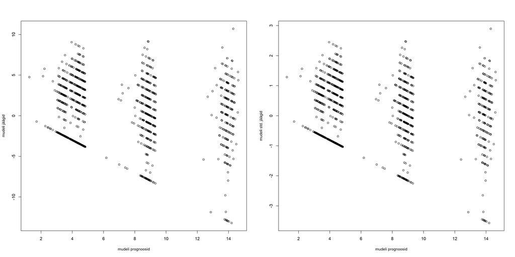

```r
par(mfrow=c(1,2))
plot(mudel_step$fitted.values,mudel_step$residuals, xlab = "mudeli prognoosid", ylab = "mudeli jäägid", cex.lab=0.9)
plot(mudel_step$fitted.values,mudel_step$residuals/sd(mudel_step$residuals), xlab = "mudeli prognoosid", ylab = "mudeli std. jäägid",cex.lab=0.9)
```

Näeme kolm põhilist vanusegrupi, transformeerime andmed vanusegruppideks

Teisendame faktor tunnused arvulisteks andmeteks, vastavalt vanusegrupile, tühistame vanad andmed andmestikust.

CAR AGE tunnus omab 25 erinevat väärtust, rühmitame need tunnused kolmeks vanusegrupiks, UUED, KESKMISED, VANAD autod

UUED (<=5) = 1  
KESKMISED (>5 & <=12) = 2  
VANAD (>12) = 3

```r
carClaims$CAR_AGE_GROUP[carClaims$CAR_AGE <= 5] <- 1
carClaims$CAR_AGE_GROUP[carClaims$CAR_AGE > 5 & carClaims$CAR_AGE <= 12] <- 2
carClaims$CAR_AGE_GROUP[carClaims$CAR_AGE > 12] <- 3
carClaims = carClaims[,-c(23)]
```

Värskendame tüübid jälle, arvulised muudame int-ks (int võtab vähem mälu kui numbriline)

```r
carClaims <- type.convert(carClaims)
```

Uurime andmestiku kokkuvõtet

```r
summary(carClaims)
```

```
##     KIDSDRIV           AGE           HOMEKIDS           YOJ
##  Min.   :0.0000   Min.   :16.00   Min.   :0.0000   Min.   : 0.00
##  1st Qu.:0.0000   1st Qu.:36.00   1st Qu.:0.0000   1st Qu.: 9.00
##  Median :0.0000   Median :42.00   Median :0.0000   Median :11.00
##  Mean   :0.2528   Mean   :43.01   Mean   :0.9665   Mean   :10.01
##  3rd Qu.:0.0000   3rd Qu.:50.00   3rd Qu.:2.0000   3rd Qu.:13.00
##  Max.   :3.0000   Max.   :76.00   Max.   :5.0000   Max.   :19.00
##      INCOME         PARENT1             HOME_VAL        MSTATUS
##  Min.   :     0   Length:2057        Min.   :     0   Length:2057
##  1st Qu.: 19122   Class :character   1st Qu.:     0   Class :character
##  Median : 40868   Mode  :character   Median :111256   Mode  :character
##  Mean   : 46669                      Mean   :111169
##  3rd Qu.: 66524                      3rd Qu.:192334
##  Max.   :290846                      Max.   :682634
##     GENDER           EDUCATION          OCCUPATION           TRAVTIME
##  Length:2057        Length:2057        Length:2057        Min.   : 5.00
##  Class :character   Class :character   Class :character   1st Qu.:24.00
##  Mode  :character   Mode  :character   Mode  :character   Median :35.00
##                                                           Mean   :35.15
##                                                           3rd Qu.:45.00
##                                                           Max.   :89.00
##    CAR_USE             BLUEBOOK          TIF           CAR_TYPE
##  Length:2057        Min.   : 1500   Min.   : 1.000   Length:2057
##  Class :character   1st Qu.: 7470   1st Qu.: 1.000   Class :character
##  Mode  :character   Median :12190   Median : 4.000   Mode  :character
##                     Mean   :13708   Mean   : 4.822
##                     3rd Qu.:18530   3rd Qu.: 7.000
##                     Max.   :48380   Max.   :21.000
##    RED_CAR             OLDCLAIM        CLM_FREQ       REVOKED
##  Length:2057        Min.   :    0   Min.   :0.000   Length:2057
##  Class :character   1st Qu.:    0   1st Qu.:0.000   Class :character
##  Mode  :character   Median : 2602   Median :1.000   Mode  :character
##                     Mean   : 6090   Mean   :1.232
##                     3rd Qu.: 6906   3rd Qu.:2.000
##                     Max.   :57037   Max.   :5.000
##     MVR_PTS          CLM_AMT       URBANICITY        CAR_AGE_GROUP
##  Min.   : 0.000   Min.   :   30   Length:2057        Min.   :1.000
##  1st Qu.: 0.000   1st Qu.: 2593   Class :character   1st Qu.:1.000
##  Median : 2.000   Median : 4130   Mode  :character   Median :2.000
##  Mean   : 2.548   Mean   : 5509                      Mean   :1.739
##  3rd Qu.: 4.000   3rd Qu.: 5686                      3rd Qu.:2.000
##  Max.   :13.000   Max.   :85524                      Max.   :3.000
```

Veendume, et kõik arvulised väärtused oleksid INT-tüüpi ja uuendame tööandmestiku üle.

```r
carClaimsNums <- carClaims[,c(1:5,7,12,14,15,18,19,21,22,24)]
carClaimsFactors <- carClaims[,c(6,8:11,13,16,17,20,23)]
str(carClaimsNums)
```

```
## 'data.frame':    2057 obs. of  14 variables:
##  $ KIDSDRIV     : int  0 1 0 0 0 0 0 0 0 0 ...
##  $ AGE          : int  34 40 34 53 45 59 28 60 32 40 ...
##  $ HOMEKIDS     : int  1 1 0 0 0 0 1 0 1 0 ...
##  $ YOJ          : int  12 11 10 14 0 12 13 12 9 11 ...
##  $ INCOME       : int  125301 50815 62978 77100 0 87460 44077 37940 31275 16989 ...
##  $ HOME_VAL     : int  0 0 0 0 106859 0 170598 182739 118160 0 ...
##  $ TRAVTIME     : int  46 21 34 15 48 45 29 16 26 20 ...
##  $ BLUEBOOK     : int  17430 18930 11200 18300 6000 15420 8710 11290 10030 12230 ...
##  $ TIF          : int  1 6 1 1 1 1 6 1 1 4 ...
##  $ OLDCLAIM     : int  0 3295 0 0 0 44857 8935 0 0 26104 ...
##  $ CLM_FREQ     : int  0 1 0 0 0 2 2 0 0 1 ...
##  $ MVR_PTS      : int  0 2 0 0 3 4 0 0 0 13 ...
##  $ CLM_AMT      : int  2946 6477 2501 6077 2920 4111 6857 5247 4486 6100 ...
##  $ CAR_AGE_GROUP: int  2 1 1 2 1 1 1 1 1 2 ...
```

```r
str(carClaimsFactors)
```

```
## 'data.frame':    2057 obs. of  10 variables:
##  $ PARENT1   : chr  "Yes" "Yes" "No" "No" ...
##  $ MSTATUS   : chr  "z_No" "z_No" "z_No" "z_No" ...
##  $ GENDER    : chr  "z_F" "M" "z_F" "z_F" ...
##  $ EDUCATION : chr  "Bachelors" "z_High School" "Bachelors" "Masters" ...
##  $ OCCUPATION: chr  "z_Blue Collar" "Manager" "Clerical" "Lawyer" ...
##  $ CAR_USE   : chr  "Commercial" "Private" "Private" "Private" ...
##  $ CAR_TYPE  : chr  "Sports Car" "Minivan" "z_SUV" "Sports Car" ...
##  $ RED_CAR   : chr  "no" "no" "no" "no" ...
##  $ REVOKED   : chr  "No" "No" "No" "No" ...
##  $ URBANICITY: chr  "Highly Urban/ Urban" "Highly Urban/ Urban" "Highly Urban/ Urban" "Highly Urban/ Urban" ...
```

Uuendame TEST/TRAIN andmestikud, kasutame sama proportsioonid 80%/20%

```r
n = nrow(carClaims)
RNGkind(sample.kind = "Rounding")
set.seed(123)
sample_index= sample(1:n,size=n,replace=F) #obj.indexit juhuslikult segatud
#treeningandmed 80%
train = sample_index[1:floor(n*.80)] #treeningandmete indeksi
test = sample_index[-train] #testandmete indeksid
carClaims_train_transf=carClaims[train,] #treeningandmed
carClaims_test_transf=carClaims[test,] #testandmed
```

Ehitame mudeli uuesti et ennustada vanuse grupi vanuse asemel.

```r
mudel_transf <- lm(CAR_AGE_GROUP ~ .,data = carClaims_train_transf)
summary(mudel_transf)
```

```
##
## Call:
## lm(formula = CAR_AGE_GROUP ~ ., data = carClaims_train_transf)
##
## Residuals:
##      Min       1Q   Median       3Q      Max
## -1.73180 -0.41308 -0.02525  0.48529  1.64702
##
## Coefficients:
##                                   Estimate Std. Error t value Pr(>|t|)
## (Intercept)                      1.132e+00  1.165e-01   9.719  < 2e-16 ***
## KIDSDRIV                        -3.318e-02  2.541e-02  -1.306  0.19170
## AGE                              2.556e-03  1.680e-03   1.522  0.12824
## HOMEKIDS                         1.539e-02  1.621e-02   0.949  0.34260
## YOJ                             -4.025e-04  3.816e-03  -0.105  0.91600
## INCOME                           5.917e-07  6.228e-07   0.950  0.34224
## PARENT1Yes                       1.281e-02  4.636e-02   0.276  0.78231
## HOME_VAL                         2.151e-08  1.750e-07   0.123  0.90218
## MSTATUSz_No                      2.944e-02  4.074e-02   0.723  0.47001
## GENDERz_F                        4.028e-02  5.097e-02   0.790  0.42954
## EDUCATIONBachelors               6.640e-01  4.701e-02  14.124  < 2e-16 ***
## EDUCATIONMasters                 1.329e+00  8.443e-02  15.742  < 2e-16 ***
## EDUCATIONPhD                     1.368e+00  1.061e-01  12.897  < 2e-16 ***
## EDUCATIONz_High School           1.139e-01  3.926e-02   2.901  0.00377 **
## OCCUPATIONDoctor                -1.078e-01  1.504e-01  -0.717  0.47372
## OCCUPATIONHome Maker            -4.981e-02  6.603e-02  -0.754  0.45073
## OCCUPATIONLawyer                -3.981e-02  9.426e-02  -0.422  0.67282
## OCCUPATIONManager               -4.553e-02  7.437e-02  -0.612  0.54051
## OCCUPATIONProfessional          -2.236e-03  5.560e-02  -0.040  0.96793
## OCCUPATIONStudent                3.814e-02  5.815e-02   0.656  0.51197
## OCCUPATIONz_Blue Collar          2.941e-02  4.546e-02   0.647  0.51783
## TRAVTIME                         1.317e-03  8.832e-04   1.491  0.13619
## CAR_USEPrivate                  -4.031e-02  4.100e-02  -0.983  0.32566
## BLUEBOOK                        -1.166e-06  2.448e-06  -0.476  0.63395
## TIF                              4.201e-03  3.323e-03   1.265  0.20623
## CAR_TYPEPanel Truck             -5.104e-02  7.915e-02  -0.645  0.51910
## CAR_TYPEPickup                   1.480e-02  4.568e-02   0.324  0.74595
## CAR_TYPESports Car               1.072e-02  5.723e-02   0.187  0.85150
## CAR_TYPEVan                     -3.400e-02  6.205e-02  -0.548  0.58378
## CAR_TYPEz_SUV                    5.885e-04  5.038e-02   0.012  0.99068
## RED_CARyes                       2.341e-02  3.983e-02   0.588  0.55680
## OLDCLAIM                        -1.471e-06  1.799e-06  -0.818  0.41376
## CLM_FREQ                         1.302e-02  1.251e-02   1.041  0.29804
## REVOKEDYes                       9.070e-03  4.121e-02   0.220  0.82583
## MVR_PTS                         -7.741e-03  5.403e-03  -1.433  0.15208
## CLM_AMT                         -3.463e-06  1.905e-06  -1.818  0.06922 .
## URBANICITYz_Highly Rural/ Rural -1.540e-02  5.971e-02  -0.258  0.79650
## ---
## Signif. codes:  0 '***' 0.001 '**' 0.01 '*' 0.05 '.' 0.1 ' ' 1
##
## Residual standard error: 0.5326 on 1608 degrees of freedom
## Multiple R-squared:  0.4254, Adjusted R-squared:  0.4126
## F-statistic: 33.07 on 36 and 1608 DF,  p-value: < 2.2e-16
```

```r
mudel_RMSE <- sqrt(sum(mudel_transf$residuals^2)/length(mudel_transf$residuals))
mudel_RMSE
```

```
## [1] 0.5265627
```

```r
mudel_step_transf <- step(mudel_transf)
```

```
## Start:  AIC=-2036.16
## CAR_AGE_GROUP ~ KIDSDRIV + AGE + HOMEKIDS + YOJ + INCOME + PARENT1 +
##     HOME_VAL + MSTATUS + GENDER + EDUCATION + OCCUPATION + TRAVTIME +
##     CAR_USE + BLUEBOOK + TIF + CAR_TYPE + RED_CAR + OLDCLAIM +
##     CLM_FREQ + REVOKED + MVR_PTS + CLM_AMT + URBANICITY
##
##              Df Sum of Sq    RSS     AIC
## - OCCUPATION  7     0.762 456.87 -2047.4
## - CAR_TYPE    5     0.302 456.41 -2045.1
## - YOJ         1     0.003 456.11 -2038.2
## - HOME_VAL    1     0.004 456.11 -2038.1
## - REVOKED     1     0.014 456.12 -2038.1
## - URBANICITY  1     0.019 456.13 -2038.1
## - PARENT1     1     0.022 456.13 -2038.1
## - BLUEBOOK    1     0.064 456.17 -2037.9
## - RED_CAR     1     0.098 456.20 -2037.8
## - MSTATUS     1     0.148 456.25 -2037.6
## - GENDER      1     0.177 456.28 -2037.5
## - OLDCLAIM    1     0.190 456.30 -2037.5
## - HOMEKIDS    1     0.256 456.36 -2037.2
## - INCOME      1     0.256 456.36 -2037.2
## - CAR_USE     1     0.274 456.38 -2037.2
## - CLM_FREQ    1     0.307 456.41 -2037.0
## - TIF         1     0.454 456.56 -2036.5
## - KIDSDRIV    1     0.484 456.59 -2036.4
## <none>                    456.11 -2036.2
## - MVR_PTS     1     0.582 456.69 -2036.1
## - TRAVTIME    1     0.630 456.74 -2035.9
## - AGE         1     0.657 456.76 -2035.8
## - CLM_AMT     1     0.938 457.04 -2034.8
## - EDUCATION   4   119.906 576.01 -1660.2
##
## Step:  AIC=-2047.41
## CAR_AGE_GROUP ~ KIDSDRIV + AGE + HOMEKIDS + YOJ + INCOME + PARENT1 +
##     HOME_VAL + MSTATUS + GENDER + EDUCATION + TRAVTIME + CAR_USE +
##     BLUEBOOK + TIF + CAR_TYPE + RED_CAR + OLDCLAIM + CLM_FREQ +
##     REVOKED + MVR_PTS + CLM_AMT + URBANICITY
##
##              Df Sum of Sq    RSS     AIC
## - CAR_TYPE    5     0.381 457.25 -2056.0
```

[output cut: 360 more lines]

```
## - TRAVTIME   1     0.721 461.06 -2074.4
## - CLM_AMT    1     0.971 461.31 -2073.5
## - CAR_USE    1     1.096 461.43 -2073.1
## - EDUCATION  4   311.329 771.66 -1233.2
##
## Step:  AIC=-2075.94
## CAR_AGE_GROUP ~ EDUCATION + TRAVTIME + CAR_USE + TIF + CLM_AMT
##
##             Df Sum of Sq    RSS     AIC
## <none>                   460.62 -2075.9
## - TIF        1      0.62 461.24 -2075.7
## - TRAVTIME   1      0.71 461.34 -2075.4
## - CAR_USE    1      0.89 461.52 -2074.8
## - CLM_AMT    1      1.12 461.75 -2073.9
## - EDUCATION  4    323.17 783.80 -1209.5
```

```r
summary(mudel_step_transf)
```

```
##
## Call:
## lm(formula = CAR_AGE_GROUP ~ EDUCATION + TRAVTIME + CAR_USE +
##     TIF + CLM_AMT, data = carClaims_train_transf)
##
## Residuals:
##      Min       1Q   Median       3Q      Max
## -1.68757 -0.42281 -0.01836  0.50962  1.58405
##
## Coefficients:
##                          Estimate Std. Error t value Pr(>|t|)
## (Intercept)             1.295e+00  5.084e-02  25.469  < 2e-16 ***
## EDUCATIONBachelors      6.733e-01  4.008e-02  16.797  < 2e-16 ***
## EDUCATIONMasters        1.318e+00  5.151e-02  25.580  < 2e-16 ***
## EDUCATIONPhD            1.361e+00  7.120e-02  19.113  < 2e-16 ***
## EDUCATIONz_High School  1.180e-01  3.762e-02   3.137  0.00173 **
## TRAVTIME                1.389e-03  8.734e-04   1.591  0.11190
## CAR_USEPrivate         -5.016e-02  2.818e-02  -1.780  0.07524 .
## TIF                     4.843e-03  3.273e-03   1.480  0.13907
## CLM_AMT                -3.718e-06  1.863e-06  -1.996  0.04615 *
## ---
## Signif. codes:  0 '***' 0.001 '**' 0.01 '*' 0.05 '.' 0.1 ' ' 1
##
## Residual standard error: 0.5306 on 1636 degrees of freedom
## Multiple R-squared:  0.4198, Adjusted R-squared:  0.4169
## F-statistic: 147.9 on 8 and 1636 DF,  p-value: < 2.2e-16
```

Mudeli R2~42%, ei parandanud mudelit, kuid saime lihtsamat formulat mis ei sisalda üleliigseid tunnuseid

Kuna meie mudel etitatud Y tunnuse ennustamiseks, mis on kategoriaalne tunnus, hakkame kasutama disklriminantanalüüsi.

## 2.5 Diskriminantanalüüs

Konstrueerime LDA mudeli

```r
library(MASS)
cars.lda = lda(CAR_AGE~.,data=carClaims_train)
summary(cars.lda)
```

```
##         Length Class  Mode
## prior    23    -none- numeric
## counts   23    -none- numeric
## means   828    -none- numeric
## scaling 792    -none- numeric
## lev      23    -none- character
## svd      22    -none- numeric
## N         1    -none- numeric
## call      3    -none- call
## terms     3    terms  call
## xlevels  10    -none- list
```

```r
yfit = predict(cars.lda,newdata=carClaims_test)
```

Kontrollime mudeli headust, koostame funktsiooni

```r
misclass = function(fit,y) {
 temp <- table(fit,y)
 cat("Table of Misclassification\n")
 cat("(row = predicted, col = actual)\n")
 print(temp)
 cat("\n\n")
 numcor <- sum(diag(temp))
 numinc <- length(y) - numcor
 mcr <- numinc/length(y)
 cat(paste("Misclassification Rate = ",format(mcr,digits=3)))
 cat("\n")
}

library(MASS)
misclass(yfit$class,carClaims_test$CAR_AGE)
```

```
## Table of Misclassification
## (row = predicted, col = actual)
##     y
## fit    1   3   4   5   6   7   8   9  10  11  12  13  14  15  16  17  18  19
##   1  137   0   3  10  20  21  22  15  11   1   1   0   0   0   0   0   0   0
##   2    0   0   1   0   0   1   0   0   0   0   0   0   0   0   0   0   0   0
##   3    0   0   0   0   0   0   0   0   0   0   0   0   0   0   0   0   0   0
##   4    0   0   0   0   0   0   0   0   0   0   0   0   0   0   0   0   0   0
##   5    2   0   0   1   0   0   0   0   0   0   0   0   0   0   0   0   0   0
##   6    0   0   0   0   0   0   0   0   0   0   0   0   0   0   0   0   0   0
##   7    1   0   0   0   0   0   0   1   0   1   0   3   0   0   0   0   0   0
##   8    0   0   0   2   0   0   2   2   2   1   0   1   2   0   1   0   1   0
##   9    4   0   0   0   1   0   3   6   0   6   3   1   1   0   1   0   0   0
##   10   2   1   0   1   2   5   4   4   1   0   0   3   0   1   0   0   0   0
##   11   2   0   0   0   0   2   2   1   1   4   5   1   0   0   0   1   0   0
```

[output cut: 40 more lines]

Võrdleme PLOT graafikud, Rühmatu CAR_AGE VS Rühmitatud CAR_AGE

```r
library(MASS)
cars.lda = lda(CAR_AGE_GROUP~.,data=carClaims_train_transf)
summary(cars.lda)
```

```
##         Length Class  Mode
## prior     3    -none- numeric
## counts    3    -none- numeric
## means   108    -none- numeric
## scaling  72    -none- numeric
## lev       3    -none- character
## svd       2    -none- numeric
## N         1    -none- numeric
## call      3    -none- call
## terms     3    terms  call
## xlevels  10    -none- list
```

```r
yfit = predict(cars.lda,newdata=carClaims_test_transf)
```

```r
misclass = function(fit,y) {
 temp <- table(fit,y)
 cat("Table of Misclassification\n")
 cat("(row = predicted, col = actual)\n")
 print(temp)
 cat("\n\n")
 numcor <- sum(diag(temp))
 numinc <- length(y) - numcor
 mcr <- numinc/length(y)
 cat(paste("Misclassification Rate = ",format(mcr,digits=3)))
 cat("\n")
}


library(MASS)
misclass(yfit$class,carClaims_test_transf$CAR_AGE_GROUP)
```

```
## Table of Misclassification
## (row = predicted, col = actual)
##    y
## fit   1   2   3
##   1 148  84   0
##   2  19  81  19
##   3   4  13  44
##
##
## Misclassification Rate =  0.337
```

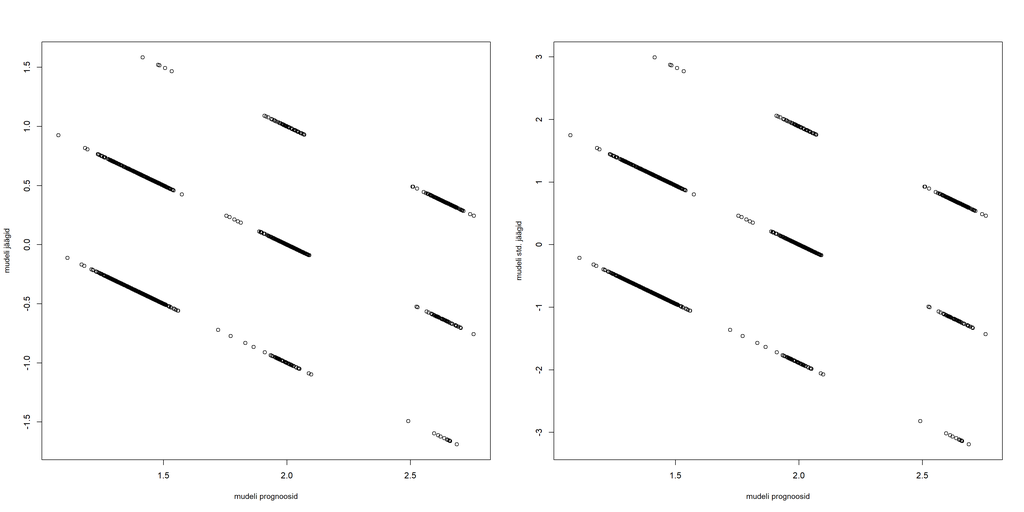

```r
par(mfrow=c(1,2))
plot(mudel_step_transf$fitted.values,mudel_step_transf$residuals, xlab = "mudeli prognoosid", ylab = "mudeli jäägid", cex.lab=0.9)
plot(mudel_step_transf$fitted.values,mudel_step_transf$residuals/sd(mudel_step_transf$residuals), xlab = "mudeli prognoosid", ylab = "mudeli std. jäägid",cex.lab=0.9)
```

On näha et andmed grupperitud kolmeks vanusegruppiks.

Võrdleme kaks step mudelit

Kontrollime jääkide normaalsust ka shapiro.test() abil:

```r
shapiro.test(mudel_step$residuals)
```

```
##
##  Shapiro-Wilk normality test
##
## data:  mudel_step$residuals
## W = 0.96449, p-value < 2.2e-16
```

```r
shapiro.test(mudel_step_transf$residuals)
```

```
##
##  Shapiro-Wilk normality test
##
## data:  mudel_step_transf$residuals
## W = 0.96015, p-value < 2.2e-16
```

Testi tulemusena saame, et p-value < 0.05. Kuna testi olulisustõenäosus (p-value) on praegu olulisuse nivoost 0.05 väiksem, saame tõestatuks lugeda, et jäägid ei ole normaaljaotusega.

Jääkide erinevus noormaaljaotusest tähendab, et mudeli on võimalik parandada, kasutades nt mittelineaarset mudelit või eemaldades andmetest erindid.

Kontrollime erindeid

```r
mudel_step$residuals[abs(mudel_step$residuals/sd(mudel_step$residuals))>4]
```

```
## named numeric(0)
```

```r
mudel_step_transf$residuals[abs(mudel_step_transf$residuals/sd(mudel_step_transf$residuals))>4]
```

```
## named numeric(0)
```

Eridina esineb 0 objekti

Võrdleme mõlemate mudelite RMSE

```r
mudel_RMSE <- sqrt(sum(mudel_step$residuals^2)/length(mudel_step$residuals))
mudel_RMSE
```

```
## [1] 3.696065
```

```r
mudel_RMSE <- sqrt(sum(mudel_step_transf$residuals^2)/length(mudel_step_transf$residuals))
mudel_RMSE
```

```
## [1] 0.5291643
```

mudel_step mudeli RMSE = 3.696065

mudel_step_transf mudeli RMSE = 0.5291643, tulemus on parem, kuna andmed gruppeeritud

```r
library(DT)
predict2 <- predict(mudel_step,newdata=carClaims_test)
carClaims_test$predict <- predict2
datatable(carClaims_test, options = list(pageLength = 20, scrollY = 300, scroller = TRUE, scrollX = T))
```

|  | KIDSDRIV | AGE | HOMEKIDS | YOJ | INCOME | PARENT1 | HOME_VAL | MSTATUS | GENDER | EDUCATION | OCCUPATION | TRAVTIME | CAR_USE | BLUEBOOK | TIF | CAR_TYPE | RED_CAR | OLDCLAIM | CLM_FREQ | REVOKED | MVR_PTS | CLM_AMT | CAR_AGE | URBANICITY | predict |
| --- | --- | --- | --- | --- | --- | --- | --- | --- | --- | --- | --- | --- | --- | --- | --- | --- | --- | --- | --- | --- | --- | --- | --- | --- | --- |
| 3305 | 0 | 37 | 0 | 11 | 22632 | No | 142769 | z_No | z_F | &lt;High School | z_Blue Collar | 56 | Private | 19970 | 13 | Pickup | no | 0 | 0 | Yes | 1 | 4813 | 7 | Highly Urban/ Urban | 3.43987331813874 |
| 6968 | 0 | 39 | 2 | 10 | 30618 | No | 157285 | Yes | M | z_High School | z_Blue Collar | 44 | Commercial | 8460 | 4 | Pickup | yes | 6403 | 2 | No | 4 | 2662 | 1 | Highly Urban/ Urban | 4.46933996293787 |
| 6912 | 0 | 35 | 2 | 10 | 71827 | No | 193298 | Yes | M | z_High School | z_Blue Collar | 46 | Commercial | 22460 | 3 | Van | no | 6029 | 1 | No | 7 | 2964 | 10 | Highly Urban/ Urban | 4.4596908976204 |
| 7522 | 1 | 40 | 1 | 6 | 24498 | Yes | 0 | z_No | z_F | z_High School | Clerical | 36 | Private | 9920 | 11 | z_SUV | no | 0 | 0 | No | 0 | 3076 | 1 | Highly Urban/ Urban | 4.30622966859936 |
| 2121 | 2 | 56 | 2 | 0 | 0 | Yes | 129145 | z_No | z_F | z_High School | Home Maker | 42 | Private | 7100 | 1 | z_SUV | no | 0 | 0 | No | 6 | 6524 | 9 | Highly Urban/ Urban | 4.19606418113361 |
| 4144 | 0 | 60 | 0 | 12 | 45038 | No | 242566 | z_No | z_F | Bachelors | Professional | 43 | Private | 17980 | 3 | Minivan | no | 0 | 0 | No | 1 | 6004 | 16 | Highly Urban/ Urban | 8.71721276887415 |
| 4130 | 0 | 38 | 1 | 17 | 14098 | No | 60733 | Yes | z_F | &lt;High School | Clerical | 27 | Private | 6710 | 10 | Sports Car | no | 3545 | 2 | No | 0 | 7893 | 1 | Highly Urban/ Urban | 3.34146563211945 |
| 3649 | 1 | 60 | 2 | 12 | 44830 | Yes | 187429 | z_No | M | z_High School | Professional | 35 | Private | 20040 | 4 | Minivan | yes | 6456 | 3 | No | 1 | 3292 | 8 | Highly Urban/ Urban | 3.9972545603171 |
| 7884 | 0 | 35 | 0 | 10 | 78260 | No | 259867 | Yes | z_F | Masters | Lawyer | 57 | Private | 23610 | 1 | z_SUV | no | 6011 | 3 | No | 9 | 4363 | 16 | Highly Urban/ Urban | 13.8672822066672 |
| 1262 | 0 | 42 | 2 | 14 | 20586 | No | 142997 | Yes | z_F | &lt;High School | Clerical | 47 | Private | 7760 | 4 | z_SUV | no | 0 | 0 | No | 0 | 5142 | 1 | z_Highly Rural/ Rural | 3.42936158804122 |

[output cut: 402 more lines]

```r
library(DT)
predict2 <- predict(mudel_step_transf,newdata=carClaims_test)
carClaims_test_transf$predict <- predict2
datatable(carClaims_test_transf, options = list(pageLength = 20, scrollY = 300, scroller = TRUE, scrollX = T))
```

|  | KIDSDRIV | AGE | HOMEKIDS | YOJ | INCOME | PARENT1 | HOME_VAL | MSTATUS | GENDER | EDUCATION | OCCUPATION | TRAVTIME | CAR_USE | BLUEBOOK | TIF | CAR_TYPE | RED_CAR | OLDCLAIM | CLM_FREQ | REVOKED | MVR_PTS | CLM_AMT | URBANICITY | CAR_AGE_GROUP | predict |
| --- | --- | --- | --- | --- | --- | --- | --- | --- | --- | --- | --- | --- | --- | --- | --- | --- | --- | --- | --- | --- | --- | --- | --- | --- | --- |
| 3305 | 0 | 37 | 0 | 11 | 22632 | No | 142769 | z_No | z_F | &lt;High School | z_Blue Collar | 56 | Private | 19970 | 13 | Pickup | no | 0 | 0 | Yes | 1 | 4813 | Highly Urban/ Urban | 2 | 1.36746029809301 |
| 6968 | 0 | 39 | 2 | 10 | 30618 | No | 157285 | Yes | M | z_High School | z_Blue Collar | 44 | Commercial | 8460 | 4 | Pickup | yes | 6403 | 2 | No | 4 | 2662 | Highly Urban/ Urban | 1 | 1.48337317771616 |
| 6912 | 0 | 35 | 2 | 10 | 71827 | No | 193298 | Yes | M | z_High School | z_Blue Collar | 46 | Commercial | 22460 | 3 | Van | no | 6029 | 1 | No | 7 | 2964 | Highly Urban/ Urban | 2 | 1.48018541496743 |
| 7522 | 1 | 40 | 1 | 6 | 24498 | Yes | 0 | z_No | z_F | z_High School | Clerical | 36 | Private | 9920 | 11 | z_SUV | no | 0 | 0 | No | 0 | 3076 | Highly Urban/ Urban | 1 | 1.45446267976402 |
| 2121 | 2 | 56 | 2 | 0 | 0 | Yes | 129145 | z_No | z_F | z_High School | Home Maker | 42 | Private | 7100 | 1 | z_SUV | no | 0 | 0 | No | 6 | 6524 | Highly Urban/ Urban | 2 | 1.40154510526578 |
| 4144 | 0 | 60 | 0 | 12 | 45038 | No | 242566 | z_No | z_F | Bachelors | Professional | 43 | Private | 17980 | 3 | Minivan | no | 0 | 0 | No | 1 | 6004 | Highly Urban/ Urban | 3 | 1.9697966143401 |
| 4130 | 0 | 38 | 1 | 17 | 14098 | No | 60733 | Yes | z_F | &lt;High School | Clerical | 27 | Private | 6710 | 10 | Sports Car | no | 3545 | 2 | No | 0 | 7893 | Highly Urban/ Urban | 1 | 1.30119275726871 |
| 3649 | 1 | 60 | 2 | 12 | 44830 | Yes | 187429 | z_No | M | z_High School | Professional | 35 | Private | 20040 | 4 | Minivan | yes | 6456 | 3 | No | 1 | 3292 | Highly Urban/ Urban | 2 | 1.41836666021052 |
| 7884 | 0 | 35 | 0 | 10 | 78260 | No | 259867 | Yes | z_F | Masters | Lawyer | 57 | Private | 23610 | 1 | z_SUV | no | 6011 | 3 | No | 9 | 4363 | Highly Urban/ Urban | 3 | 2.63014331339238 |
| 1262 | 0 | 42 | 2 | 14 | 20586 | No | 142997 | Yes | z_F | &lt;High School | Clerical | 47 | Private | 7760 | 4 | z_SUV | no | 0 | 0 | No | 0 | 5142 | z_Highly Rural/ Rural | 1 | 1.31014380263171 |

[output cut: 402 more lines]

Tulemuste võrdlemine

Antud diagrammidel vasakult auto vanus ei ole rühmitatud, paremalt pool rühmitatud

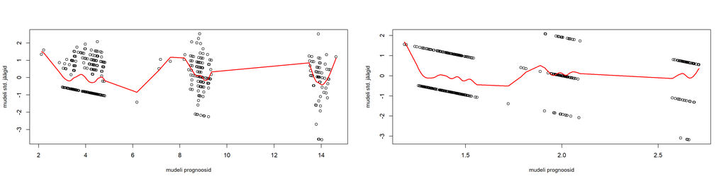

```r
par(mfrow=c(1,2))
plot(carClaims_test$predict,(carClaims_test$CAR_AGE-carClaims_test$predict)/sd(carClaims_test$CAR_AGE-carClaims_test$predict), xlab = "mudeli prognoosid", ylab = "mudeli std. jäägid",cex.lab=0.9)
lines(smooth.spline(carClaims_test$predict,(carClaims_test$CAR_AGE-carClaims_test$predict)/sd(carClaims_test$CAR_AGE-carClaims_test$predict),spar=0.8), col='red', lwd=2)
plot(carClaims_test_transf$predict,(carClaims_test_transf$CAR_AGE_GROUP-carClaims_test_transf$predict)/sd(carClaims_test_transf$CAR_AGE_GROUP-carClaims_test_transf$predict), xlab = "mudeli prognoosid", ylab = "mudeli std. jäägid",cex.lab=0.9)
lines(smooth.spline(carClaims_test_transf$predict,(carClaims_test_transf$CAR_AGE_GROUP-carClaims_test_transf$predict)/sd(carClaims_test_transf$CAR_AGE_GROUP-carClaims_test_transf$predict),spar=0.8), col='red', lwd=2)
```

Võrdleme graafiliselt

Auto vanus ei ole rühmitatud

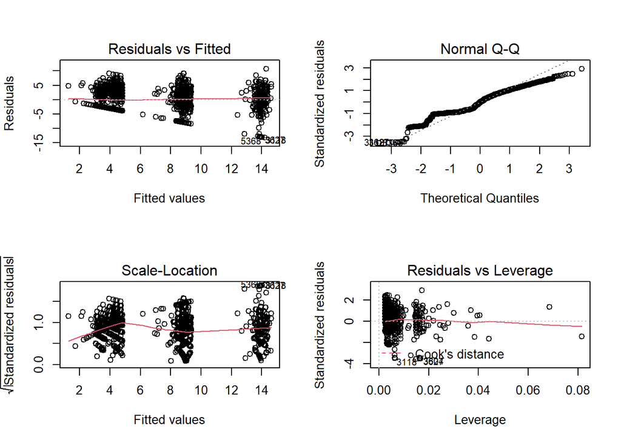

```r
par(mfrow=c(2,2))
plot(lm(mudel_step))
```

Auto vanus rühmitatud

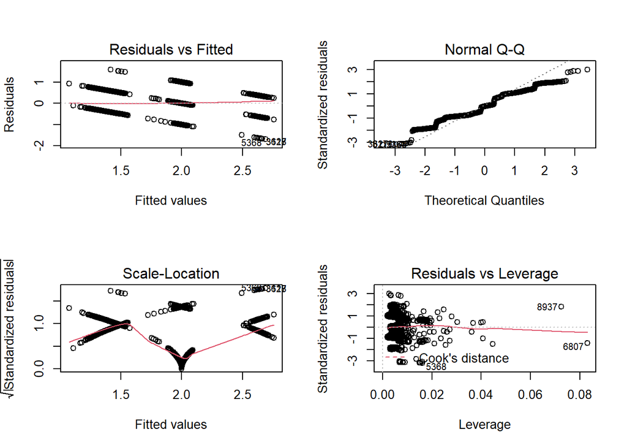

```r
par(mfrow=c(2,2))
plot(lm(mudel_step_transf))
```

Kontrollime multikollineaarsust

Auto vanus ei ole rühmitatud

```r
library(car)
vif(mudel_step)
```

```
##               GVIF Df GVIF^(1/(2*Df))
## GENDER    1.111210  1        1.054140
## EDUCATION 1.155078  4        1.018184
## CAR_USE   1.256705  1        1.121029
## CLM_AMT   1.009422  1        1.004700
```

Auto vanus rühmitatud

```r
library(car)
vif(mudel_step_transf)
```

```
##               GVIF Df GVIF^(1/(2*Df))
## EDUCATION 1.153778  4        1.018041
## TRAVTIME  1.017044  1        1.008486
## CAR_USE   1.150055  1        1.072406
## TIF       1.003596  1        1.001797
## CLM_AMT   1.008657  1        1.004319
```

vif < 5, mis näitab et multikollineaarsust ei ole.

Võrdleme mudeli prognoose tunnuse Y tegelike väärtustega fitted/predicted vs actual diagrammil. Ideaalis punktid peavad paiknema y=x punasel joonel. Scatterploti siledav sinine joon näitab tegelikku tendentsi.

Auto vanus ei ole rühmitatud vs Auto vanus rühmitatud

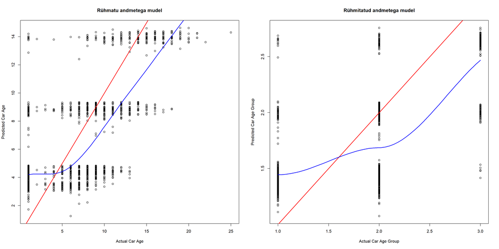

```r
par(mfrow=c(1,2))
plot(carClaims_train$CAR_AGE,mudel_step$fitted.values,xlab="Actual Car Age",ylab="Predicted Car Age", main = "Rühmatu andmetega mudel")
abline(0,1,lwd=2,col="red")
lines(loess.smooth(carClaims_train$CAR_AGE,mudel_step$fitted.values), col='blue', lwd=2)
plot(carClaims_train_transf$CAR_AGE_GROUP,mudel_step_transf$fitted.values,xlab="Actual Car Age Group",ylab="Predicted Car Age Group", main = "Rühmitatud andmetega mudel")
abline(0,1,lwd=2,col="red")
lines(loess.smooth(carClaims_train_transf$CAR_AGE_GROUP,mudel_step_transf$fitted.values), col='blue', lwd=2,)
```

Gruppeeritud andmetega diagrammil on andmed 1-3ni, ja gruppeerimata 1-25

On näha et mudel üsna ebatäpne

Mudeli käitumine testandmetel

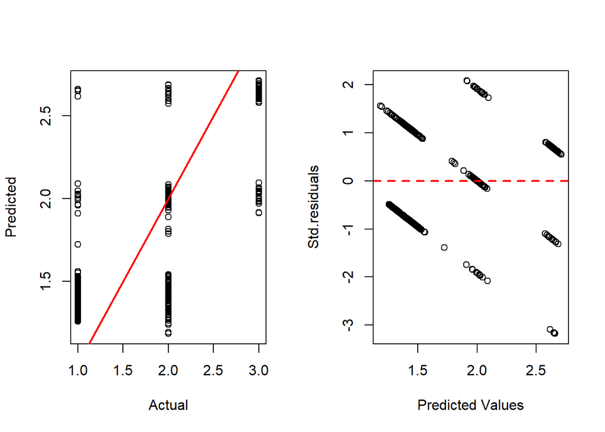

```r
ypred <- predict(mudel_step_transf,newdata=carClaims_test_transf)
y_test <- carClaims_test_transf[,24]
par(mfrow=c(1,2))
plot(y_test,ypred,xlab="Actual",ylab="Predicted")
abline(0,1,lwd=2,col="red")
plot(ypred,(y_test-ypred)/sd(y_test-ypred),xlab="Predicted Values",ylab="Std.residuals")
abline(h=0,lwd=2,col="red", lty=2)
```

```r
cor(y_test, ypred)^2 # R-squared
```

```
## [1] 0.4571229
```

Testandmetel mudeli viga on R2=0.4571229

Saame vea väärtust ka testandmetel korduvalt mõõta (Monte Carlo Split-Sample Cross-validation):

```r
test.cv = function(mudel,y,data,p=.2,k=20)
{
 n = length(y)
 cv_rmse <- rep(0,k)
 cv_r2 <-  rep(0,k)
 for (i in 1:k) {
 sam <- sample(1:n,floor(n*p),replace=F)
 ypred <- predict(mudel,newdata=data[-sam,])
 cv_rmse[i] <- sqrt(mean((y[-sam]-ypred)^2))
 cv_r2[i] <-cor(y[-sam], ypred)^2
 }
 out <- c(mean(cv_rmse),mean(cv_r2))
 names(out) <- c("RMSE","Rsquared")
 out
}
test.cv(mudel_step_transf,carClaims_test_transf[,24],carClaims_test_transf,p=.2,k=20)
```

```
##      RMSE  Rsquared
## 0.5204689 0.4610009
```

Proovime faktorandmete teisendamist

```r
library(caret)
carClaims.PP = preProcess(carClaims_train_transf, method = list(BoxCox = c("CAR_AGE_GROUP"),YeoJohnson=c("PARENT1","MSTATUS","GENDER", "EDUCATION", "OCCUPATION", "CAR_USE", "CAR_TYPE", "RED_CAR", "REVOKED")))
carClaims.PP
```

```
## Created from 1645 samples and 11 variables
##
## Pre-processing:
##   - Box-Cox transformation (1)
##   - ignored (10)
##
## Lambda estimates for Box-Cox transformation:
## 0
```

Box-cox

```r
carClaims.PP$bc
```

```
## $CAR_AGE_GROUP
## Box-Cox Transformation
##
## 1645 data points used to estimate Lambda
##
## Input data summary:
##    Min. 1st Qu.  Median    Mean 3rd Qu.    Max.
##   1.000   1.000   2.000   1.733   2.000   3.000
##
## Largest/Smallest: 3
## Sample Skewness: 0.413
##
## Estimated Lambda: 0
## With fudge factor, Lambda = 0 will be used for transformations
```

Box-com pakub ainult üks väärtus labmdaga=0 ja ignoreerib 10 ülejäänud tunnust.

Yeo-Johnsoni ei kasutatud faktooride jaoks, seega on see NULL

```r
carClaims$PP$yj
```

Prognoositava tunnuse Y teisendamine. Dispersiooni stabiliseerimine.

```r
summary(powerTransform(carClaims_train_transf$CAR_AGE_GROUP))
```

```
## bcPower Transformation to Normality
##                                      Est Power Rounded Pwr Wald Lwr Bnd
## carClaims_train_transf$CAR_AGE_GROUP    0.0118           0      -0.1355
##                                      Wald Upr Bnd
## carClaims_train_transf$CAR_AGE_GROUP       0.1591
##
## Likelihood ratio test that transformation parameter is equal to 0
##  (log transformation)
##                              LRT df    pval
## LR test, lambda = (0) 0.02444692  1 0.87575
##
## Likelihood ratio test that no transformation is needed
##                            LRT df       pval
## LR test, lambda = (1) 184.6825  1 < 2.22e-16
```

Tõenäosuse suhte test, et muundamist pole vaja.

LDA tulemuste visualiseerimine

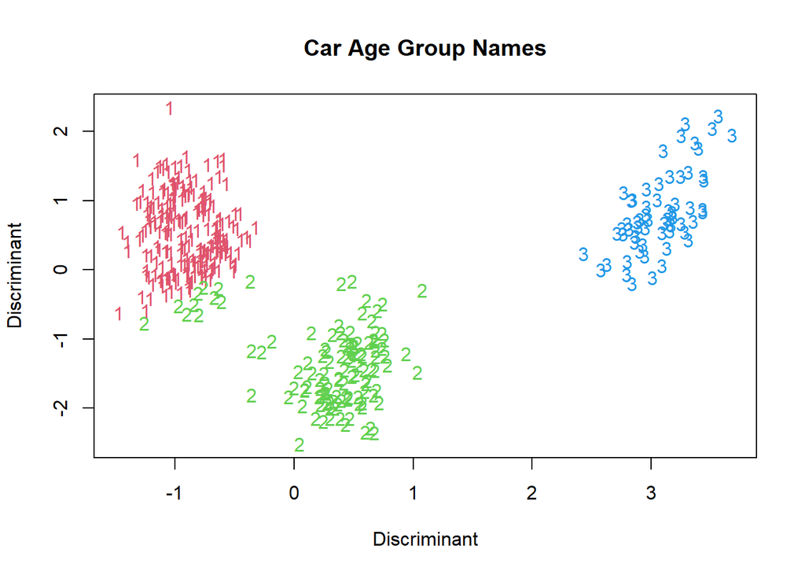

```r
plot(yfit$x[,1],yfit$x[,2],type="n",xlab="Discriminant",
 ylab="Discriminant",main="Car Age Group Names")
text(yfit$x[,1],yfit$x[,2],as.character(yfit$class),col=as.numeric(yfit$class)+1,
 cex=1)
```

```r
yfit_test = predict(cars.lda,newdata=carClaims_test_transf[,-24])
```

Rühmad on hästi eraldatud

Lisame eelmisele graafikule veel prognoosid

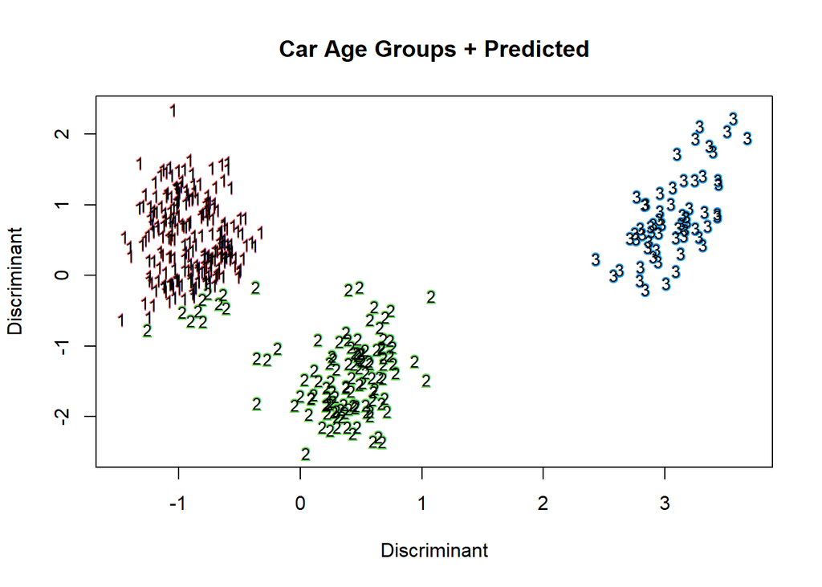

```r
plot(yfit$x[,1],yfit$x[,2],type="n",xlab="Discriminant",
 ylab="Discriminant",main="Car Age Groups + Predicted")
text(yfit$x[,1],yfit$x[,2],as.character(yfit$class),col=as.numeric(yfit$class)+1,
 cex=1)
yfit_test = predict(cars.lda,newdata=carClaims_test_transf[,-24])
text(yfit_test$x[,1],yfit_test$x[,2],as.character(yfit_test$class),cex=.8)
```

On näha et ennustatavad tunnused asuvad sarnastes asukohtades graafiku peal kui ka tõelised andmed

# 3 Kokkuvõte

Prjektis sooritati järgmised etapid:

1. andmete ettevalmistamine, puhastamine
2. andmete kirjeldamine ja esmaanalüüs
3. mitmemõõtmeline lineaarne regressioon (MLR) (sh sammregressioon)
4. MLR parandamise võtmed (muutujate teisendamine, mittelineaarsete komponentide lisamine, erindite ja multikollineaarsuse eemaldamine)
5. diskriminantanalüüs

Uurimuse käigus saadi tulemused järgnevalt:  
1) mitmemõõtmeline lineaarne regressioon mudeli kirjeldusvõime:  
rühmatu andmete mudel = 49%  
rühmatu andmete mudel RMSE = 3.673968  
rühmatu andmete step mudel = 48%  
rühmatu andmete step mudel RMSE = 3.696065

rühmitatud andmete mudel = 43%  
rühmitatud andmete mudel RMSE = 0.5265627  
rühmitatud andmete step mudel = 42%  
rühmitatud andmete step mudel RMSE = 0.5291643

rühmatu LDA mudeli misclassification Rate = 0.65  
rühmitatud LDA mudeli misclassification Rate = 0.34

Esmaanalüüs näitab , et andmed on hästi rühmitatud ning hea tulemuse saavutamiseks tuleb enustada vanuse rühma täpse vanuse asemel. Autovanuse ennustamise kindlustusjuhtumi andmete järgi jaoks kasutasime autode vanuste rühmitamine ja diskriminantanalüüsi. LDA mudel gruppeeritud andmetel annab täpsema ennustamisvõimet (0.34 vs 0.65). MLR mudeli jaoks sammregressioon lihtsustab formulat kuid tähtsusetult vähendab kirjeldamisvõimet (1% võrra), samas kergelt suurendab RMSE.

# 4 Kasutatud materjalid

1. Projektis on kasustatud kursuses MEM5210 Mitmemõõtmeline statistiline analüüs esitatud õppematerialid ja harjutused.
2. https://www.kaggle.com/xiaomengsun/car-insurance-claim-data

# 5 Lisa

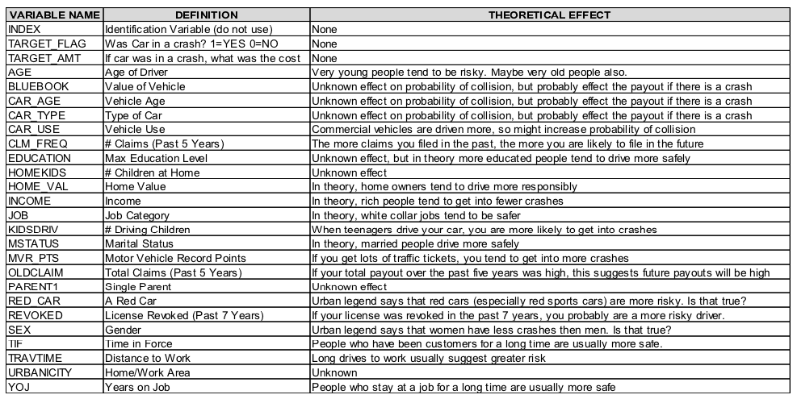

Andmestiku kirjeldus